# PresentableData

Eduardo Montes

2026-03-03

Link to the dataset on kaggle:https://www.kaggle.com/datasets/datasnaek/chess

```r
library(tidyverse)
games <- read_csv("games.csv")
```

This allows us to see what are the variable and variable types that are in this dataset.

```r
str(games)
```

```
## spc_tbl_ [20,058 × 16] (S3: spec_tbl_df/tbl_df/tbl/data.frame)
##  $ id            : chr [1:20058] "TZJHLljE" "l1NXvwaE" "mIICvQHh" "kWKvrqYL" ...
##  $ rated         : logi [1:20058] FALSE TRUE TRUE TRUE TRUE FALSE ...
##  $ created_at    : num [1:20058] 1.5e+12 1.5e+12 1.5e+12 1.5e+12 1.5e+12 ...
##  $ last_move_at  : num [1:20058] 1.5e+12 1.5e+12 1.5e+12 1.5e+12 1.5e+12 ...
##  $ turns         : num [1:20058] 13 16 61 61 95 5 33 9 66 119 ...
##  $ victory_status: chr [1:20058] "outoftime" "resign" "mate" "mate" ...
##  $ winner        : chr [1:20058] "white" "black" "white" "white" ...
##  $ increment_code: chr [1:20058] "15+2" "5+10" "5+10" "20+0" ...
##  $ white_id      : chr [1:20058] "bourgris" "a-00" "ischia" "daniamurashov" ...
##  $ white_rating  : num [1:20058] 1500 1322 1496 1439 1523 ...
##  $ black_id      : chr [1:20058] "a-00" "skinnerua" "a-00" "adivanov2009" ...
##  $ black_rating  : num [1:20058] 1191 1261 1500 1454 1469 ...
##  $ moves         : chr [1:20058] "d4 d5 c4 c6 cxd5 e6 dxe6 fxe6 Nf3 Bb4+ Nc3 Ba5 Bf4" "d4 Nc6 e4 e5 f4 f6 dxe5 fxe5 fxe5 Nxe5 Qd4 Nc6 Qe5+ Nxe5 c4 Bb4+" "e4 e5 d3 d6 Be3 c6 Be2 b5 Nd2 a5 a4 c5 axb5 Nc6 bxc6 Ra6 Nc4 a4 c3 a3 Nxa3 Rxa3 Rxa3 c4 dxc4 d5 cxd5 Qxd5 exd5 "| __truncated__ "d4 d5 Nf3 Bf5 …
##  $ opening_eco   : chr [1:20058] "D10" "B00" "C20" "D02" ...
##  $ opening_name  : chr [1:20058] "Slav Defense: Exchange Variation" "Nimzowitsch Defense: Kennedy Variation" "King's Pawn Game: Leonardis Variation" "Queen's Pawn Game: Zukertort Variation" ...
##  $ opening_ply   : num [1:20058] 5 4 3 3 5 4 10 5 6 4 ...
##  - attr(*, "spec")=
##   .. cols(
##   ..   id = col_character(),
##   ..   rated = col_logical(),
##   ..   created_at = col_double(),
##   ..   last_move_at = col_double(),
##   ..   turns = col_double(),
##   ..   victory_status = col_character(),
##   ..   winner = col_character(),
##   ..   increment_code = col_character(),
##   ..   white_id = col_character(),
##   ..   white_rating = col_double(),
##   ..   black_id = col_character(),
##   ..   black_rating = col_double(),
##   ..   moves = col_character(),
##   ..   opening_eco = col_character(),
##   ..   opening_name = col_character(),
##   ..   opening_ply = col_double()
##   .. )
##  - attr(*, "problems")=<externalptr>
```

We are looking at 9 categorical and 6 numerical variable. id, white_id, black_id are ordinal variables victory_status, increment_code, moves, opening_eco, opening_name are nominal variables winner is a binary variable

created_at, last_move_at, turns, white_rating, black_rating are continuous variables

opening_ply is a discrete variable.

I gained a lot of interest in seeing what kind of data can be pulled from chess matches, especially how does starting first effect the outcome of each match. I also want to see if the number of turns it takes for a match to end is linked the average of the players in each match. A basic summary of the data set is that we are seeing how 20000 matches were played. The dataset provides the the ratings of the white pieces and black pieces, the number of turns taken in each game, the result of the games and their winners, and we get to see information on the opening plays like the names and how many moves it takes to complete the opening play.

This code below begins manipulating the data by focusing on the winners of the matches and leaving out the games the ended in draws. It also counts how many times the white pieces won and how many times the black pieces have won and then calculating the avgerage rating in between the players in each match.

```r
games_clean <- games %>%
  filter(winner %in% c("white","black")) %>%
  mutate(
    white_win = ifelse(winner == "white", 1, 0),
    black_win = ifelse(winner == "black", 1, 0),

    # rating difference
    rating_diff = white_rating - black_rating,

    # average rating for the match
    avg_rating = (white_rating + black_rating)/2
  )
```

Looking at the win rate between both color pieces.

```r
games_clean %>%
  summarize(white_win_rate = mean(white_win), black_win_rate = mean(black_win))
```

```
## # A tibble: 1 × 2
##   white_win_rate black_win_rate
##            <dbl>          <dbl>
## 1          0.523          0.477
```

We can do a proportion test on winners that were white pieces to go from win rate to probablity of how often white will win.

```r
prop.test(
  x = sum(games_clean$winner == "white"),
  n = nrow(games_clean),
  p = 0.5
)
```

```
##
##  1-sample proportions test with continuity correction
##
## data:  sum(games_clean$winner == "white") out of nrow(games_clean), null probability 0.5
## X-squared = 41.734, df = 1, p-value = 1.046e-10
## alternative hypothesis: true p is not equal to 0.5
## 95 percent confidence interval:
##  0.5162815 0.5304957
## sample estimates:
##         p
## 0.5233933
```

Graph to see the number of games won between players with black pieces and white pieces. White has the advantage of starting first and being able to almost dictate the pace and the space of the board with thier first move. This can force the black pieces to already begin on the back foot. This allows for the white pieces to have a higher chance at winning the match.

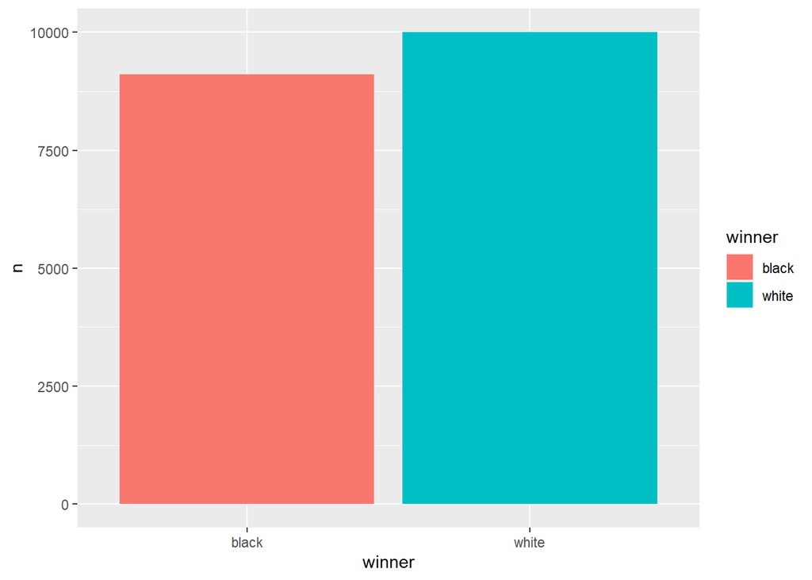

```r
games_clean %>%
  count(winner) %>%
  ggplot(aes(x = winner, y = n, fill = winner))+
  geom_bar(stat="identity")
```

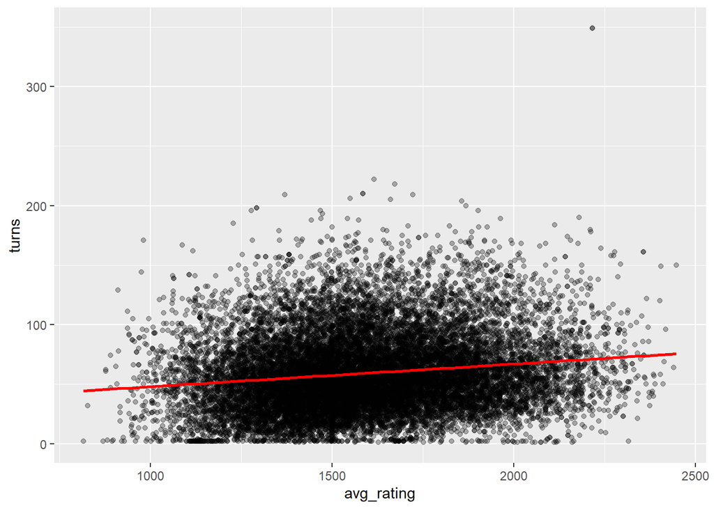

```r
ggplot(games_clean, aes(x = avg_rating, y = turns))+
  geom_point(alpha = 0.3)+
  geom_smooth(method="lm", color = "red")
```

We are looking at negative and positive correlation to see how ratings affect how many turns occur in one match. With this correlation, negative tells us that there higher rating players take less time to finish their games and positive shows that the higher players will take more time to finish their matches.

```r
cor.test(games_clean$avg_rating, games_clean$turns)
```

```
##
##  Pearson's product-moment correlation
##
## data:  games_clean$avg_rating and games_clean$turns
## t = 21.562, df = 19106, p-value < 2.2e-16
## alternative hypothesis: true correlation is not equal to 0
## 95 percent confidence interval:
##  0.1402566 0.1679411
## sample estimates:
##       cor
## 0.1541291
```

This linear regression model tells us the same information as the correlation a more negative linear model shows that the higher rated players will finish their matches faster.

```r
model <- lm(turns ~ avg_rating, data = games_clean)
summary(model)
```

```
##
## Call:
## lm(formula = turns ~ avg_rating, data = games_clean)
##
## Residuals:
##     Min      1Q  Median      3Q     Max
## -71.011 -22.609  -4.674  17.431 277.874
##
## Coefficients:
##              Estimate Std. Error t value Pr(>|t|)
## (Intercept) 28.918516   1.422732   20.33   <2e-16 ***
## avg_rating   0.019038   0.000883   21.56   <2e-16 ***
## ---
## Signif. codes:  0 '***' 0.001 '**' 0.01 '*' 0.05 '.' 0.1 ' ' 1
##
## Residual standard error: 31.92 on 19106 degrees of freedom
## Multiple R-squared:  0.02376,    Adjusted R-squared:  0.0237
## F-statistic: 464.9 on 1 and 19106 DF,  p-value: < 2.2e-16
```